# MIS-64036: Business Analytics Assignment I

Sumanth

10/16/2019

1. 1. What is the probability of obtaining a score greater than 700 on a GMAT test that has a mean of 494 and a standard deviation of 100? Assume GMAT scores are normally distributed (5 marks).
2. What is the probability of getting a score between 350 and 450 on the same GMAT exam?(5 marks)

```r
1-pnorm(700, mean = 494, sd= 100)
```

```
## [1] 0.01969927
```

```r
pnorm(450,mean=494,sd=100)-pnorm(350,mean=494,sd=100)
```

```
## [1] 0.2550349
```

2. Runzheimer International publishes business travel costs for various cities throughout the world. In particular, they publish per diem totals, which represent the average costs for the typical business traveler including three meals a day in business-class restaurants and single-rate lodging in business-class hotels and motels. If 86.65% of the per diem costs in Buenos Aires, Argentina, are less than $449 and if the standard deviation of per diem costs is $36, what is the average per diem cost in Buenos Aires? Assume that per diem costs are normally distributed (10 marks)

```r
U=449-(qnorm(0.8665)*36)
U
```

```
## [1] 409.0401
```

3. Chris is interested in understanding the correlation between temperature in Kent, OH and Los Angeles, CA. He has got the following data for September 2017 from Alpha Knowledgebase. (5 marks)

```r
K<-c(59, 68, 78, 60)
LA<-c(90, 82, 78, 75)
k_mean <-  mean(K)
LA_mean  <- mean(LA)
num <- sum((K-k_mean)*(LA-LA_mean))
C1 <- sqrt(sum((K-k_mean)^2))
C2 <- sqrt(sum((LA-LA_mean)^2))
C <- C1 * C2
r = num / C
r     #Correlation
```

```
## [1] -0.3566049
```

4. Show the breakdown of the number of transactions by countries i.e. how many transactions are in the dataset for each country (consider all records including cancelled transactions). Show this in total number and also in percentage. Show only countries accounting for more than 1% of the total transactions. (5 marks)

```r
Retail <- read.csv("Online_Retail.csv")

#Solution 4
summary(Retail$Country)
```

```
##            Australia              Austria              Bahrain
##                 1259                  401                   19
##              Belgium               Brazil               Canada
##                 2069                   32                  151
##      Channel Islands               Cyprus       Czech Republic
##                  758                  622                   30
##              Denmark                 EIRE   European Community
##                  389                 8196                   61
##              Finland               France              Germany
##                  695                 8557                 9495
##               Greece            Hong Kong              Iceland
##                  146                  288                  182
##               Israel                Italy                Japan
##                  297                  803                  358
##              Lebanon            Lithuania                Malta
##                   45                   35                  127
##          Netherlands               Norway               Poland
##                 2371                 1086                  341
##             Portugal                  RSA         Saudi Arabia
##                 1519                   58                   10
##            Singapore                Spain               Sweden
##                  229                 2533                  462
##          Switzerland United Arab Emirates       United Kingdom
##                 2002                   68               495478
##          Unspecified                  USA
##                  446                  291
```

```r
Country_totalnumber <- table(Retail$Country)
transaction_percent <-round(100*prop.table(Country_totalnumber), digits = 2)
percentage <- cbind(Country_totalnumber,transaction_percent)
answer <- subset(percentage,transaction_percent>1)
answer
```

```
##                Country_totalnumber transaction_percent
## EIRE                          8196                1.51
## France                        8557                1.58
## Germany                       9495                1.75
## United Kingdom              495478               91.43
```

5. Create a new variable âTransactionValueâ that is the product of the exising âQuantityâ and âUnitPriceâ variables. Add this variable to the dataframe. (5 marks)

```r
library(dplyr)
Retail <- Retail %>% mutate(TransactionValue= Quantity * UnitPrice)
summary(Retail$TransactionValue)
```

```
##       Min.    1st Qu.     Median       Mean    3rd Qu.       Max.
## -168469.60       3.40       9.75      17.99      17.40  168469.60
```

6. Using the newly created variable, TransactionValue, show the breakdown of transaction values by countries i.e. how much money in total has been spent each country. Show this in total sum of transaction values. Show only countries with total transaction exceeding 130,000 British Pound. (10 marks)

```r
data <- summarise(group_by(Retail,Country),sum_1= sum(TransactionValue))
Transaction <- filter(data,sum_1 >130000)
Transaction
```

```
## # A tibble: 6 x 2
##   Country           sum_1
##   <fct>             <dbl>
## 1 Australia       137077.
## 2 EIRE            263277.
## 3 France          197404.
## 4 Germany         221698.
## 5 Netherlands     284662.
## 6 United Kingdom 8187806.
```

7. This is an optional question which carries additional marks (golden questions).

```r
Temp=strptime(Retail$InvoiceDate,format='%m/%d/%Y %H:%M',tz='GMT')
head(Temp)
```

```
## [1] "2010-12-01 08:26:00 GMT" "2010-12-01 08:26:00 GMT"
## [3] "2010-12-01 08:26:00 GMT" "2010-12-01 08:26:00 GMT"
## [5] "2010-12-01 08:26:00 GMT" "2010-12-01 08:26:00 GMT"
```

```r
Retail$New_Invoice_Date <- as.Date(Temp)
Retail$New_Invoice_Date[20000]-Retail$New_Invoice_Date[10]
```

```
## Time difference of 8 days
```

```r
Retail$Invoice_Day_Week= weekdays(Retail$New_Invoice_Date)
Retail$New_Invoice_Hour = as.numeric(format(Temp, "%H"))
Retail$New_Invoice_Month = as.numeric(format(Temp, "%m"))

#7(a)
a<-summarise(group_by(Retail,Invoice_Day_Week),Transaction_Value=n_distinct(InvoiceNo))
a1<-mutate(a, transaction_percent=(Transaction_Value/sum(Transaction_Value))*100)
a1
```

```
## # A tibble: 6 x 3
##   Invoice_Day_Week Transaction_Value transaction_percent
##   <chr>                        <int>               <dbl>
## 1 Friday                        4184               16.2
## 2 Monday                        4138               16.0
## 3 Sunday                        2381                9.19
## 4 Thursday                      5660               21.9
## 5 Tuesday                       4722               18.2
## 6 Wednesday                     4815               18.6
```

```r
#7(b)

b1<-summarise(group_by(Retail,Invoice_Day_Week),Transaction_Volume=sum(TransactionValue))
b2<-mutate(b1,percentage=(Transaction_Volume/sum(Transaction_Volume))*100)
b2
```

```
## # A tibble: 6 x 3
##   Invoice_Day_Week Transaction_Volume percentage
##   <chr>                         <dbl>      <dbl>
## 1 Friday                     1540611.      15.8
## 2 Monday                     1588609.      16.3
## 3 Sunday                      805679.       8.27
## 4 Thursday                   2112519       21.7
## 5 Tuesday                    1966183.      20.2
## 6 Wednesday                  1734147.      17.8
```

```r
#7(c)
c1<-summarise(group_by(Retail,New_Invoice_Month),Transaction_Volume=sum(TransactionValue))
c1<-mutate(c1,percentage=(Transaction_Volume/sum(Transaction_Volume))*100)
c1
```

```
## # A tibble: 12 x 3
##    New_Invoice_Month Transaction_Volume percentage
##                <dbl>              <dbl>      <dbl>
##  1                 1            560000.       5.74
##  2                 2            498063.       5.11
##  3                 3            683267.       7.01
##  4                 4            493207.       5.06
##  5                 5            723334.       7.42
##  6                 6            691123.       7.09
##  7                 7            681300.       6.99
##  8                 8            682681.       7.00
##  9                 9           1019688.      10.5
## 10                10           1070705.      11.0
## 11                11           1461756.      15.0
## 12                12           1182625.      12.1
```

```r
#7(d)
Retail <- Retail %>% mutate(TransactionValue= Quantity * UnitPrice)

Retail %>% filter(Country == 'Australia') %>% group_by(New_Invoice_Date) %>% summarise(max=max(TransactionValue))
```

```
## # A tibble: 49 x 2
##    New_Invoice_Date     max
##    <date>             <dbl>
##  1 2010-12-01         51
##  2 2010-12-08         71.4
##  3 2010-12-14         -6.25
##  4 2010-12-17        148.
##  5 2011-01-06       1020
##  6 2011-01-10         81.6
##  7 2011-01-11         35.4
##  8 2011-01-14        142.
##  9 2011-01-17         47.4
## 10 2011-01-19         38.2
## # ... with 39 more rows
```

```r
#7(e)
e1<-summarise(group_by(Retail,New_Invoice_Hour),Transaction_min=n_distinct(InvoiceNo))
e1<-filter(e1,New_Invoice_Hour>=7&New_Invoice_Hour<=20)
#e12<-rollapply(e1$Transaction_min,3,sum)
#e123<-which.min(e12)
```

8. Plot the histogram of transaction values from Germany. Use the hist() function to plot.

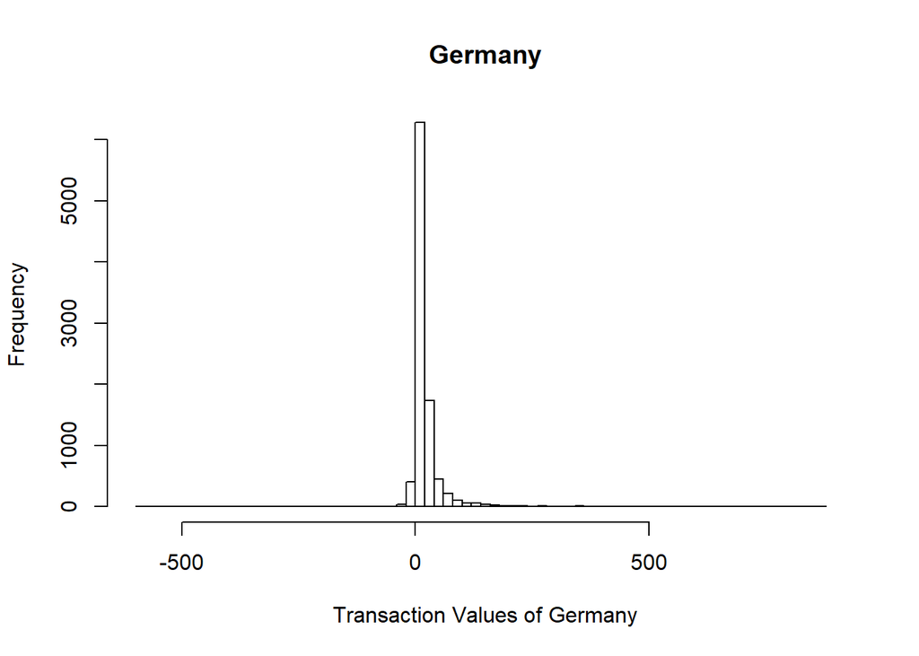

```r
Germany_data <- subset(Retail$TransactionValue, Retail$Country == "Germany")
hist(Germany_data, xlim = c (-600, 900), breaks = 100 , xlab = "Transaction Values of Germany", main = "Germany")
```

9. Which customer had the highest number of transactions? Which customer is most valuable (i.e. highest total sum of transactions)?

```r
Retail1 <- na.omit(Retail)
result1 <- summarise(group_by(Retail1,CustomerID), sum2= sum(TransactionValue))
result1[which.max(result1$sum2),]
```

```
## # A tibble: 1 x 2
##   CustomerID    sum2
##        <int>   <dbl>
## 1      14646 279489.
```

```r
data2 <- table(Retail$CustomerID)
data2 <- as.data.frame(data2)
result2 <- data2[which.max(data2$Freq),]
result2
```

```
##       Var1 Freq
## 4043 17841 7983
```

10. Calculate the percentage of missing values for each variable in the dataset (5 marks). Hint colMeans():

```r
missing_values <- colMeans(is.na(Retail)*100)
missing_values
```

```
##         InvoiceNo         StockCode       Description          Quantity
##           0.00000           0.00000           0.00000           0.00000
##       InvoiceDate         UnitPrice        CustomerID           Country
##           0.00000           0.00000          24.92669           0.00000
##  TransactionValue  New_Invoice_Date  Invoice_Day_Week  New_Invoice_Hour
##           0.00000           0.00000           0.00000           0.00000
## New_Invoice_Month
##           0.00000
```

11. What are the number of transactions with missing CustomerID records by countries? (10 marks)

```r
Retail2 <- Retail %>% filter(is.na(CustomerID)) %>% group_by(Country)
summary(Retail2$Country)
```

```
##            Australia              Austria              Bahrain
##                    0                    0                    2
##              Belgium               Brazil               Canada
##                    0                    0                    0
##      Channel Islands               Cyprus       Czech Republic
##                    0                    0                    0
##              Denmark                 EIRE   European Community
##                    0                  711                    0
##              Finland               France              Germany
##                    0                   66                    0
##               Greece            Hong Kong              Iceland
##                    0                  288                    0
##               Israel                Italy                Japan
##                   47                    0                    0
##              Lebanon            Lithuania                Malta
##                    0                    0                    0
##          Netherlands               Norway               Poland
##                    0                    0                    0
##             Portugal                  RSA         Saudi Arabia
##                   39                    0                    0
##            Singapore                Spain               Sweden
##                    0                    0                    0
##          Switzerland United Arab Emirates       United Kingdom
##                  125                    0               133600
##          Unspecified                  USA
##                  202                    0
```

13. In the retail sector, it is very important to understand the return rate of the goods purchased by customers. In this example, we can define this quantity, simply, as the ratio of the number of transactions cancelled (regardless of the transaction value) over the total number of transactions. With this definition, what is the return rate for the French customers? (10 marks). Consider the cancelled transactions as those where the âQuantityâ variable has a negative value.

```r
Retail_table <- filter(Retail,Country=="France")
totalrow <- nrow(Retail_table)
cancel <- nrow(subset(Retail_table,TransactionValue<0))
cancel
```

```
## [1] 149
```

```r
notcancel <- totalrow-cancel
notcancel
```

```
## [1] 8408
```

```r
TEST2=(cancel/8556)
TEST2
```

```
## [1] 0.01741468
```

14. What is the product that has generated the highest revenue for the retailer? (i.e. item with the highest total sum of âTransactionValueâ)(10 marks)

```r
Transaction_Value <- tapply(Retail$TransactionValue, Retail$StockCode  , sum)
Transaction_Value[which.max(Transaction_Value)]
```

```
##      DOT
## 206245.5
```

15. How many unique customers are represented in the dataset? You can use unique() and length() functions. (5 marks)

```r
unique_customers <- unique(Retail$CustomerID)

length(unique_customers)
```

```
## [1] 4373
```